# Lobyerev V1

Itai van Rijn

February 24, 2019

## Implimatation of Lobyerev & Hoffman (2008) Selectivity model

This document describes the implimatation of the selectivity algorithem described in Lobyrev, Feodor, and Matthew J. Hoffman. “A morphological and geometric method for estimating the selectivity of gill nets.” Reviews in Fish Biology and Fisheries 28.4 (2018): 909-924.

### Step 1: Import field data on fish catch and gill net properties

#### Step 1.1: Import catch data

Catch data structure: Column 1: ‘Mesh_size’ - name of the net (later conected to net properties under the same name) Column 2: ‘Length_group’ - Fish total length (cm) Column 3: ‘Wedged’ - Number of wedged individuals Column 4: ‘Tangled’ - Number of tangled individuals

```r
Catch.data.Cod <- read.csv("~/kinneret modeling/selectivity/R code Feodor paper/Data/Catch data Cod.csv")
#Show the first 6 lines:
print(head(Catch.data.Cod))
```

```
##   Mesh_size Length_group Wedged Tangled
## 1        20           14      2       2
## 2        20           16     20       5
## 3        20           18     15      12
## 4        20           20     11       8
## 5        20           22     20      18
## 6        20           24     32      24
```

#### Step 1.2: Import table of net properties

Net properties data structure: (See Figure 2 in paper) Column 1: ‘Mesh_size’ - mesh size (knot to knot) (mm) Column 2: ‘y’ - Smaller of the angels between mesh threads

```r
net.properties <- read.csv("~/kinneret modeling/selectivity/R code Feodor paper/Data/net properties.csv")
#Show table:
print(net.properties)
```

```
##   Mesh_size  y
## 1        20 60
## 2        25 60
## 3        30 60
```

#### Step 1.3: Add angel in Radian

```r
net.properties$Radian=0.018*net.properties$y
#Show table:
print(net.properties)
```

```
##   Mesh_size  y Radian
## 1        20 60   1.08
## 2        25 60   1.08
## 3        30 60   1.08
```

#### Step 1.4: Define the angel between the end of upper and lower jaws (phi)

```r
phi_deg=7
phi_radian=0.018*phi_deg
```

#### Step 1.5: Calculate the jaw length approximated by the linear function

```r
slope_jaw=1.02
intecept_jaw=3.41
Catch.data.Cod$Jaw_length=intecept_jaw + (slope_jaw*Catch.data.Cod$Length_group)
#Calculate h
Catch.data.Cod$h=Catch.data.Cod$Jaw_length * sin(phi_radian) * 2
print(head(Catch.data.Cod))
```

```
##   Mesh_size Length_group Wedged Tangled Jaw_length        h
## 1        20           14      2       2      17.69 4.446094
## 2        20           16     20       5      19.73 4.958815
## 3        20           18     15      12      21.77 5.471535
## 4        20           20     11       8      23.81 5.984256
## 5        20           22     20      18      25.85 6.496977
## 6        20           24     32      24      27.89 7.009698
```

#### Step 1.6: Merge the catch data with the net data

```r
Catch.data.Cod=merge(Catch.data.Cod,net.properties,by="Mesh_size")
#print first 6 lines
print(head(Catch.data.Cod))
```

```
##   Mesh_size Length_group Wedged Tangled Jaw_length        h  y Radian
## 1        20           14      2       2      17.69 4.446094 60   1.08
## 2        20           16     20       5      19.73 4.958815 60   1.08
## 3        20           18     15      12      21.77 5.471535 60   1.08
## 4        20           20     11       8      23.81 5.984256 60   1.08
## 5        20           22     20      18      25.85 6.496977 60   1.08
## 6        20           24     32      24      27.89 7.009698 60   1.08
```

### Step 2: Calculate P(O|C) and P(Th|C)

For calculating P(O|C) use eq. 4 in the paper

```r
#Calculate sin,cos,tan
Catch.data.Cod$sin=sin(0.5*Catch.data.Cod$Radian)
Catch.data.Cod$cos=cos(0.5*Catch.data.Cod$Radian)
Catch.data.Cod$tan=tan(0.5*Catch.data.Cod$Radian)
#Calculate P(O|C) Eq. 4
Catch.data.Cod$POC=(((Catch.data.Cod$cos * Catch.data.Cod$Mesh_size)-Catch.data.Cod$h)*((Catch.data.Cod$sin*Catch.data.Cod$Mesh_size)-(Catch.data.Cod$tan*Catch.data.Cod$h)))/(Catch.data.Cod$cos*Catch.data.Cod$sin*(Catch.data.Cod$Mesh_size)^2)
#Calculate P(Th|c)
Catch.data.Cod$PThC=1-Catch.data.Cod$POC
#Print first 6 rows
print(head(Catch.data.Cod))
```

```
##   Mesh_size Length_group Wedged Tangled Jaw_length        h  y Radian
## 1        20           14      2       2      17.69 4.446094 60   1.08
## 2        20           16     20       5      19.73 4.958815 60   1.08
## 3        20           18     15      12      21.77 5.471535 60   1.08
## 4        20           20     11       8      23.81 5.984256 60   1.08
## 5        20           22     20      18      25.85 6.496977 60   1.08
## 6        20           24     32      24      27.89 7.009698 60   1.08
##        sin       cos       tan       POC      PThC
## 1 0.514136 0.8577087 0.5994296 0.5488078 0.4511922
## 2 0.514136 0.8577087 0.5994296 0.5054167 0.4945833
## 3 0.514136 0.8577087 0.5994296 0.4638123 0.5361877
## 4 0.514136 0.8577087 0.5994296 0.4239946 0.5760054
## 5 0.514136 0.8577087 0.5994296 0.3859636 0.6140364
## 6 0.514136 0.8577087 0.5994296 0.3497193 0.6502807
```

### Step 3: Calculate P(W|E)

!!!!I just import the data from yur Excel, but do not know how the calculation was made

```r
PWE <- read.csv("~/kinneret modeling/selectivity/R code Feodor paper/Data/PWE.csv", stringsAsFactors=FALSE)
print(PWE)
```

```
##    Mesh_size Length_group  PWE
## 1         20           14 0.35
## 2         20           16 0.69
## 3         20           18 0.81
## 4         20           20 0.88
## 5         20           22 0.88
## 6         20           24 1.00
## 7         20           26 1.00
## 8         20           28 1.00
## 9         20           30 1.00
## 10        20           32 1.00
## 11        20           34 1.00
## 12        20           36 1.00
## 13        20           38 1.00
## 14        20           40 1.00
```

[output cut: 37 more lines]

```r
#merge with table 'Catch.data.Cod'
Catch.data.Cod=merge(Catch.data.Cod,PWE ,by=c("Mesh_size",    "Length_group"))
```

### Step 4: Calculate Eq. 2

#### Step 4.1: Calculate P(E|O) by the linear equation

```r
##Get the min and max size groups for each net
#Create table
net_PEO=data.frame(Mesh_size=unique(Catch.data.Cod$Mesh_size))
#Length group interval
Length_group_interval=2
#The minimal size for each net
min_wedged=data.frame(Catch.data.Cod %>%
   filter(!is.na(Wedged)) %>%
  group_by(Mesh_size) %>%
  summarize(min_size = min(Length_group, na.rm = TRUE)))
#The maximal size for each net
max_wedged=data.frame(Catch.data.Cod %>%
   filter(!is.na(Wedged)) %>%
  group_by(Mesh_size) %>%
  summarize(max_size = max(Length_group, na.rm = TRUE)))
#merge
net_PEO=merge(net_PEO,min_wedged,by="Mesh_size")
net_PEO=merge(net_PEO,max_wedged,by="Mesh_size")
#Substract and add the Length group interval
net_PEO$min_size=net_PEO$min_size-(Length_group_interval/2)
net_PEO$max_size=net_PEO$max_size+(Length_group_interval/2)
#Calculate the linear function
net_PEO$slope=-1/(net_PEO$max_size-net_PEO$min_size)
net_PEO$intercept=1-(net_PEO$slope*net_PEO$min_size)
#print
print(net_PEO)
```

```
##   Mesh_size min_size max_size       slope intercept
## 1        20       13       31 -0.05555556  1.722222
## 2        25       17       35 -0.05555556  1.944444
## 3        30       21       37 -0.06250000  2.312500
```

```r
#Calculate PEO
#Merge slope and intercept to data
Catch.data.Cod=merge(Catch.data.Cod,net_PEO,by="Mesh_size")
Catch.data.Cod$PEO=Catch.data.Cod$intercept+(Catch.data.Cod$Length_group)*Catch.data.Cod$slope
#Remove PEO values if no fish were wedged
Catch.data.Cod[is.na(Catch.data.Cod$Wedged),"PEO"]=NA
#Print first 6 lines
print(head(Catch.data.Cod))
```

```
##   Mesh_size Length_group Wedged Tangled Jaw_length        h  y Radian
## 1        20           14      2       2      17.69 4.446094 60   1.08
## 2        20           16     20       5      19.73 4.958815 60   1.08
## 3        20           18     15      12      21.77 5.471535 60   1.08
## 4        20           20     11       8      23.81 5.984256 60   1.08
## 5        20           22     20      18      25.85 6.496977 60   1.08
## 6        20           24     32      24      27.89 7.009698 60   1.08
##        sin       cos       tan       POC      PThC  PWE min_size max_size
## 1 0.514136 0.8577087 0.5994296 0.5488078 0.4511922 0.35       13       31
## 2 0.514136 0.8577087 0.5994296 0.5054167 0.4945833 0.69       13       31
## 3 0.514136 0.8577087 0.5994296 0.4638123 0.5361877 0.81       13       31
## 4 0.514136 0.8577087 0.5994296 0.4239946 0.5760054 0.88       13       31
## 5 0.514136 0.8577087 0.5994296 0.3859636 0.6140364 0.88       13       31
## 6 0.514136 0.8577087 0.5994296 0.3497193 0.6502807 1.00       13       31
##         slope intercept       PEO
## 1 -0.05555556  1.722222 0.9444444
## 2 -0.05555556  1.722222 0.8333333
## 3 -0.05555556  1.722222 0.7222222
## 4 -0.05555556  1.722222 0.6111111
## 5 -0.05555556  1.722222 0.5000000
## 6 -0.05555556  1.722222 0.3888889
```

#### Step 4.2: Claculate Eq.2

```r
Catch.data.Cod$Ntotal=Catch.data.Cod$Wedged/(Catch.data.Cod$POC*Catch.data.Cod$PWE*Catch.data.Cod$PEO)
#Print first 6 lines
print(head(Catch.data.Cod))
```

```
##   Mesh_size Length_group Wedged Tangled Jaw_length        h  y Radian
## 1        20           14      2       2      17.69 4.446094 60   1.08
## 2        20           16     20       5      19.73 4.958815 60   1.08
## 3        20           18     15      12      21.77 5.471535 60   1.08
## 4        20           20     11       8      23.81 5.984256 60   1.08
## 5        20           22     20      18      25.85 6.496977 60   1.08
## 6        20           24     32      24      27.89 7.009698 60   1.08
##        sin       cos       tan       POC      PThC  PWE min_size max_size
## 1 0.514136 0.8577087 0.5994296 0.5488078 0.4511922 0.35       13       31
## 2 0.514136 0.8577087 0.5994296 0.5054167 0.4945833 0.69       13       31
## 3 0.514136 0.8577087 0.5994296 0.4638123 0.5361877 0.81       13       31
## 4 0.514136 0.8577087 0.5994296 0.4239946 0.5760054 0.88       13       31
## 5 0.514136 0.8577087 0.5994296 0.3859636 0.6140364 0.88       13       31
## 6 0.514136 0.8577087 0.5994296 0.3497193 0.6502807 1.00       13       31
##         slope intercept       PEO    Ntotal
## 1 -0.05555556  1.722222 0.9444444  11.02466
## 2 -0.05555556  1.722222 0.8333333  68.81967
## 3 -0.05555556  1.722222 0.7222222  55.28320
## 4 -0.05555556  1.722222 0.6111111  48.24247
## 5 -0.05555556  1.722222 0.5000000 117.76900
## 6 -0.05555556  1.722222 0.3888889 235.29074
```

### Step 5: Calculate CPUE

(table 21)

```r
#Define the number of trials
n_trials=11
#Aggregate catch for each mesh size
Catch.data.Cod$CPUE=rowSums(Catch.data.Cod[,c("Wedged","Tangled")],na.rm=T)/n_trials
#Print first 6 lines
print(head(Catch.data.Cod))
```

```
##   Mesh_size Length_group Wedged Tangled Jaw_length        h  y Radian
## 1        20           14      2       2      17.69 4.446094 60   1.08
## 2        20           16     20       5      19.73 4.958815 60   1.08
## 3        20           18     15      12      21.77 5.471535 60   1.08
## 4        20           20     11       8      23.81 5.984256 60   1.08
## 5        20           22     20      18      25.85 6.496977 60   1.08
## 6        20           24     32      24      27.89 7.009698 60   1.08
##        sin       cos       tan       POC      PThC  PWE min_size max_size
## 1 0.514136 0.8577087 0.5994296 0.5488078 0.4511922 0.35       13       31
## 2 0.514136 0.8577087 0.5994296 0.5054167 0.4945833 0.69       13       31
## 3 0.514136 0.8577087 0.5994296 0.4638123 0.5361877 0.81       13       31
## 4 0.514136 0.8577087 0.5994296 0.4239946 0.5760054 0.88       13       31
## 5 0.514136 0.8577087 0.5994296 0.3859636 0.6140364 0.88       13       31
## 6 0.514136 0.8577087 0.5994296 0.3497193 0.6502807 1.00       13       31
##         slope intercept       PEO    Ntotal      CPUE
## 1 -0.05555556  1.722222 0.9444444  11.02466 0.3636364
## 2 -0.05555556  1.722222 0.8333333  68.81967 2.2727273
## 3 -0.05555556  1.722222 0.7222222  55.28320 2.4545455
## 4 -0.05555556  1.722222 0.6111111  48.24247 1.7272727
## 5 -0.05555556  1.722222 0.5000000 117.76900 3.4545455
## 6 -0.05555556  1.722222 0.3888889 235.29074 5.0909091
```

### Step 6: Calculate Nw per hour

(table 23)

```r
#Define number of hours of single (??) field trial
n_hours=12
Catch.data.Cod$Ntotal_per_hour=Catch.data.Cod$Ntotal/n_hours
#Print first 6 lines
print(head(Catch.data.Cod))
```

```
##   Mesh_size Length_group Wedged Tangled Jaw_length        h  y Radian
## 1        20           14      2       2      17.69 4.446094 60   1.08
## 2        20           16     20       5      19.73 4.958815 60   1.08
## 3        20           18     15      12      21.77 5.471535 60   1.08
## 4        20           20     11       8      23.81 5.984256 60   1.08
## 5        20           22     20      18      25.85 6.496977 60   1.08
## 6        20           24     32      24      27.89 7.009698 60   1.08
##        sin       cos       tan       POC      PThC  PWE min_size max_size
## 1 0.514136 0.8577087 0.5994296 0.5488078 0.4511922 0.35       13       31
## 2 0.514136 0.8577087 0.5994296 0.5054167 0.4945833 0.69       13       31
## 3 0.514136 0.8577087 0.5994296 0.4638123 0.5361877 0.81       13       31
## 4 0.514136 0.8577087 0.5994296 0.4239946 0.5760054 0.88       13       31
## 5 0.514136 0.8577087 0.5994296 0.3859636 0.6140364 0.88       13       31
## 6 0.514136 0.8577087 0.5994296 0.3497193 0.6502807 1.00       13       31
##         slope intercept       PEO    Ntotal      CPUE Ntotal_per_hour
## 1 -0.05555556  1.722222 0.9444444  11.02466 0.3636364       0.9187218
## 2 -0.05555556  1.722222 0.8333333  68.81967 2.2727273       5.7349724
## 3 -0.05555556  1.722222 0.7222222  55.28320 2.4545455       4.6069330
## 4 -0.05555556  1.722222 0.6111111  48.24247 1.7272727       4.0202057
## 5 -0.05555556  1.722222 0.5000000 117.76900 3.4545455       9.8140830
## 6 -0.05555556  1.722222 0.3888889 235.29074 5.0909091      19.6075616
```

### Step 7:

#### Step 7.1: SLl,t for each length class as Ntotal-Qt

(table 24)

```r
Catch.data.Cod$SL_l_t=Catch.data.Cod$Ntotal_per_hour-Catch.data.Cod$CPUE
#Print first 6 lines
print(head(Catch.data.Cod))
```

```
##   Mesh_size Length_group Wedged Tangled Jaw_length        h  y Radian
## 1        20           14      2       2      17.69 4.446094 60   1.08
## 2        20           16     20       5      19.73 4.958815 60   1.08
## 3        20           18     15      12      21.77 5.471535 60   1.08
## 4        20           20     11       8      23.81 5.984256 60   1.08
## 5        20           22     20      18      25.85 6.496977 60   1.08
## 6        20           24     32      24      27.89 7.009698 60   1.08
##        sin       cos       tan       POC      PThC  PWE min_size max_size
## 1 0.514136 0.8577087 0.5994296 0.5488078 0.4511922 0.35       13       31
## 2 0.514136 0.8577087 0.5994296 0.5054167 0.4945833 0.69       13       31
## 3 0.514136 0.8577087 0.5994296 0.4638123 0.5361877 0.81       13       31
## 4 0.514136 0.8577087 0.5994296 0.4239946 0.5760054 0.88       13       31
## 5 0.514136 0.8577087 0.5994296 0.3859636 0.6140364 0.88       13       31
## 6 0.514136 0.8577087 0.5994296 0.3497193 0.6502807 1.00       13       31
##         slope intercept       PEO    Ntotal      CPUE Ntotal_per_hour
## 1 -0.05555556  1.722222 0.9444444  11.02466 0.3636364       0.9187218
## 2 -0.05555556  1.722222 0.8333333  68.81967 2.2727273       5.7349724
## 3 -0.05555556  1.722222 0.7222222  55.28320 2.4545455       4.6069330
## 4 -0.05555556  1.722222 0.6111111  48.24247 1.7272727       4.0202057
## 5 -0.05555556  1.722222 0.5000000 117.76900 3.4545455       9.8140830
## 6 -0.05555556  1.722222 0.3888889 235.29074 5.0909091      19.6075616
##       SL_l_t
## 1  0.5550854
## 2  3.4622451
## 3  2.1523876
## 4  2.2929329
## 5  6.3595376
## 6 14.5166525
```

#### Step 7.2: N_AP calculation

First the table of Nlim (table 22c) is defined, in reality it is in input

!!!Notice- value of tau is very sensetive to the sum of the CPUE

```r
###The next data frame will be an experimental input
n_lim=data.frame(Mesh_size=c(20,25,30),Nlim=c(36,32,12))
#Sum CPUE per net
CPUE=data.frame(Catch.data.Cod %>%
  group_by(Mesh_size) %>%
  summarize(CPUE_sum = sum(CPUE, na.rm = TRUE)))
#merge to n_lim table
n_lim=merge(n_lim,CPUE,by="Mesh_size")
#Calculate tau (table 25)
n_lim$tau=n_hours/(-log(1-(n_lim$CPUE/n_lim$Nlim)))
n_lim$N_AP=((n_lim$Nlim*(1.71))/n_lim$tau)*n_hours
print(n_lim)
```

```
##   Mesh_size Nlim CPUE_sum       tau     N_AP
## 1        20   36 25.09091 10.050904 73.49787
## 2        25   32 26.27273  6.974731 94.14557
## 3        30   12 11.72727  3.171088 77.65157
```

#### Step 7.3: Size specific N_AP

!!!In table 26 you use data from table 24 (SL)- is SL=0 if there is no value for this length group in table 24?

```r
#Replace NA's in column 'SL_l_t' with 0
Catch.data.Cod[is.na(Catch.data.Cod$SL_l_t),"SL_l_t"]=0
#merge
Catch.data.Cod=merge(Catch.data.Cod,n_lim,by="Mesh_size")
#Calculate N_AP per size class
Catch.data.Cod$N_AP_size=(Catch.data.Cod$N_AP*(Catch.data.Cod$CPUE/Catch.data.Cod$CPUE_sum))+Catch.data.Cod$SL_l_t
print(head(Catch.data.Cod))
```

```
##   Mesh_size Length_group Wedged Tangled Jaw_length        h  y Radian
## 1        20           14      2       2      17.69 4.446094 60   1.08
## 2        20           16     20       5      19.73 4.958815 60   1.08
## 3        20           18     15      12      21.77 5.471535 60   1.08
## 4        20           20     11       8      23.81 5.984256 60   1.08
## 5        20           22     20      18      25.85 6.496977 60   1.08
## 6        20           24     32      24      27.89 7.009698 60   1.08
##        sin       cos       tan       POC      PThC  PWE min_size max_size
## 1 0.514136 0.8577087 0.5994296 0.5488078 0.4511922 0.35       13       31
## 2 0.514136 0.8577087 0.5994296 0.5054167 0.4945833 0.69       13       31
## 3 0.514136 0.8577087 0.5994296 0.4638123 0.5361877 0.81       13       31
## 4 0.514136 0.8577087 0.5994296 0.4239946 0.5760054 0.88       13       31
## 5 0.514136 0.8577087 0.5994296 0.3859636 0.6140364 0.88       13       31
## 6 0.514136 0.8577087 0.5994296 0.3497193 0.6502807 1.00       13       31
##         slope intercept       PEO    Ntotal      CPUE Ntotal_per_hour
## 1 -0.05555556  1.722222 0.9444444  11.02466 0.3636364       0.9187218
## 2 -0.05555556  1.722222 0.8333333  68.81967 2.2727273       5.7349724
## 3 -0.05555556  1.722222 0.7222222  55.28320 2.4545455       4.6069330
## 4 -0.05555556  1.722222 0.6111111  48.24247 1.7272727       4.0202057
## 5 -0.05555556  1.722222 0.5000000 117.76900 3.4545455       9.8140830
## 6 -0.05555556  1.722222 0.3888889 235.29074 5.0909091      19.6075616
##       SL_l_t Nlim CPUE_sum     tau     N_AP N_AP_size
## 1  0.5550854   36 25.09091 10.0509 73.49787  1.620272
## 2  3.4622451   36 25.09091 10.0509 73.49787 10.119661
## 3  2.1523876   36 25.09091 10.0509 73.49787  9.342396
## 4  2.2929329   36 25.09091 10.0509 73.49787  7.352569
## 5  6.3595376   36 25.09091 10.0509 73.49787 16.478809
## 6 14.5166525   36 25.09091 10.0509 73.49787 29.429263
```

### Step 8: Calculate selectivity

(table 28)

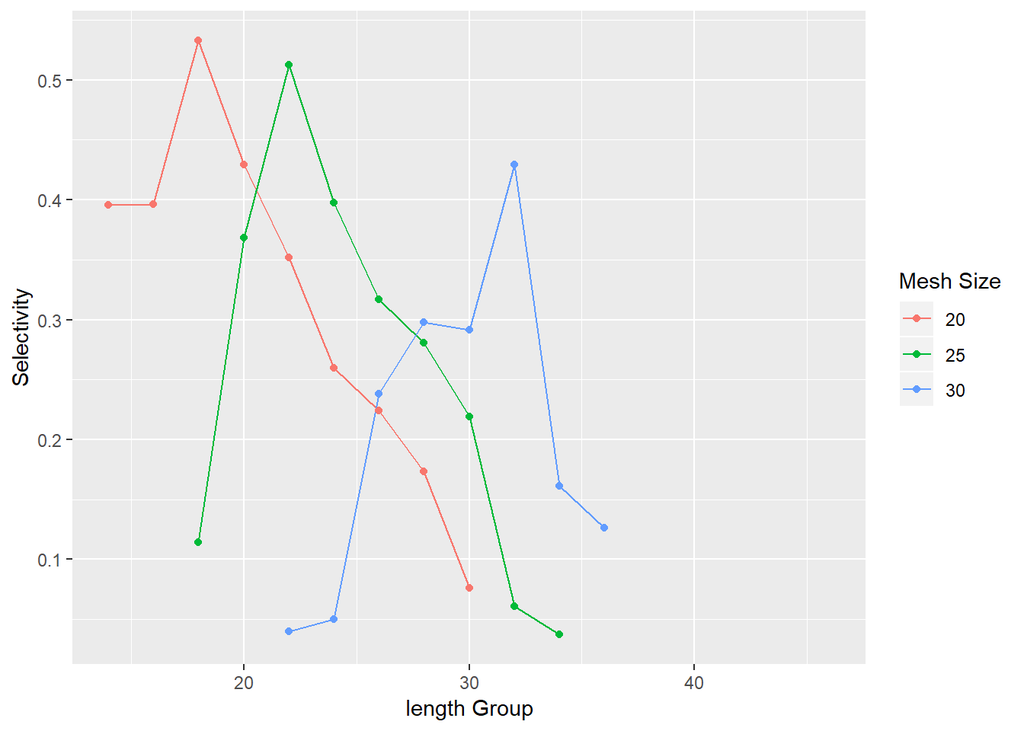

```r
##Calculate selectivity
Catch.data.Cod$selectivity=Catch.data.Cod$CPUE/Catch.data.Cod$Ntotal_per_hour
##plot
Catch.data.Cod$Mesh_size_fac=as.character(Catch.data.Cod$Mesh_size)
ggplot(Catch.data.Cod, aes(x=Length_group, y=selectivity, group=Mesh_size_fac)) +
  geom_line(aes(color=Mesh_size_fac))+
  geom_point(aes(color=Mesh_size_fac))+
   labs(x = "length Group",y="Selectivity",color="Mesh Size")
```